# GenoPred Report

Testing mode was used, restricting analyses to chromosome 22.

Sample: example_plink1

Family ID: 1_EUR

Individual ID: 1_EUR

# Target Descriptives

- The target sample contains 12 individuals.
- The target genotype data was provided in plink1 format. Of the 17679 variants in the reference, 17679 were available in the target (100%).

# Ancestry

- The target individual matches the EUR reference population with a probability >50%.

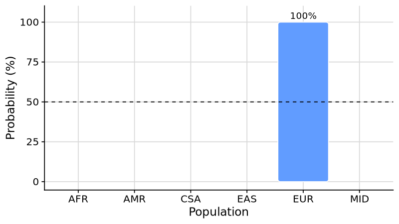

Ancestry inference: Population probabilities.

Note. The dashed line indicates the probability threshold used for ancestry classification.

# Polygenic Scores

- 2 GWAS summary statistics were provided for polygenic scoring.
- 2 PGS methods were applied, including pT+clump, DBSLMM.
- 3 external score files were provided for polygenic scoring.

## GWAS summary statistics

| Name | Label | Population | NSNP Original | NSNP Final |
| --- | --- | --- | --- | --- |
| BODY04 | Body Mass Index | EUR | 2554615 | 14999 |
| COAD01 | Coronary Artery Disease | EUR | 9455778 | 17110 |

## Score files

| Name | Label | NSNP Original | NSNP Final | Pass |
| --- | --- | --- | --- | --- |
| PGS000001 | Breast Cancer | 3 | 1 | False |
| PGS002804 | Height Yengo EUR | 15379 | 14263 | True |
| PGS003980 | BMI | 14977 | 14765 | True |

**Note.** The `Pass` column indicates whether a sufficient number of variants within the score file were present in the reference data.

## Target Polygenic Profile

### Method: DBSLMM

| Outcome | PGS Descriptives PGS R-squared | PGS Descriptives PGS AUC | Distribution in General Population Prevelance | Distribution in General Population Mean | Distribution in General Population SD | Distribution in People Like You PGS Z-score | Distribution in People Like You Prevalence | Distribution in People Like You Mean | Distribution in People Like You SD |
| --- | --- | --- | --- | --- | --- | --- | --- | --- | --- |
| Body Mass Index | 0.002 | NA | NA | 0 | 1 | 0.673 | NA | 0.034 | 0.999 |
| Coronary Artery Disease | 0.001 | 0.5 | 0.03 | NA | NA | -1.602 | 0.03 | NA | NA |

**Note.** PGS R-squared/AUC is estimated via pseudovalidation, and may be inaccurate. To specify alternative parameters, check out our [interactive tool](https://opain.github.io/GenoPred/PRS_to_Abs_tool.html) for converting polygenic scores to the absolute scale.

#### GWAS: Body Mass Index

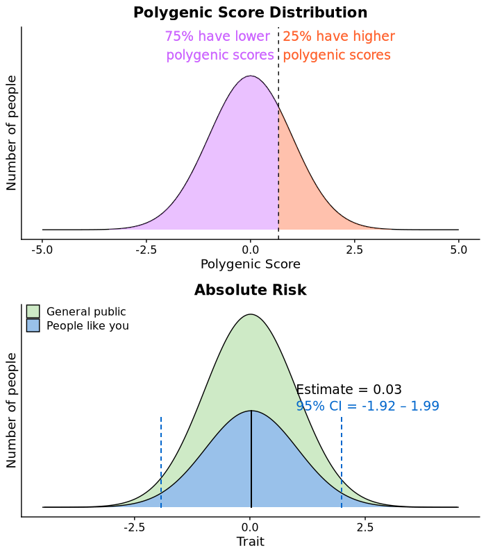

#### GWAS: Coronary Artery Disease

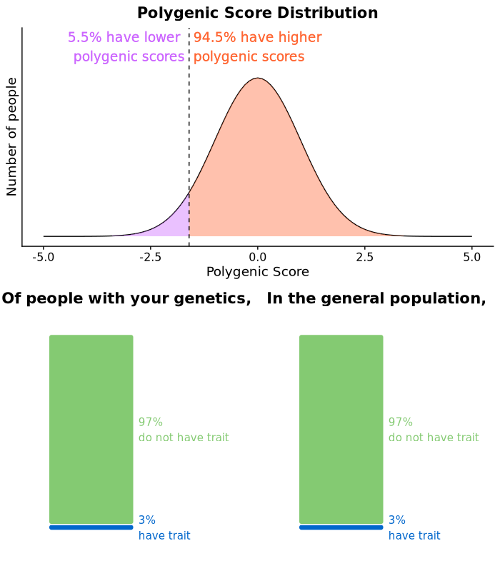

- Your PGS Z-score for Coronary Artery DiseaseCoronary Artery Disease is -1.602 which is higher than 5.5% of other EUR individuals.
- Assuming the PGS has an AUC of 0.5, and the prevelance of Coronary Artery Disease in the general population is 0.03, on average 3% of people with your PGS have Coronary Artery Disease.
- **Note.** These predictions are estimated using a range of assumptions and should be interpreted with caution. This report is merely a demonstration of how polygenic scores can be interpreted.

### Method: pT+clump

| Outcome | PGS Descriptives PGS R-squared | PGS Descriptives PGS AUC | Distribution in General Population Prevelance | Distribution in General Population Mean | Distribution in General Population SD | Distribution in People Like You PGS Z-score | Distribution in People Like You Prevalence | Distribution in People Like You Mean | Distribution in People Like You SD |
| --- | --- | --- | --- | --- | --- | --- | --- | --- | --- |
| Body Mass Index | 0.002 | NA | NA | 0 | 1 | 1.847 | NA | 0.092 | 0.999 |
| Coronary Artery Disease | 0.001 | 0.5 | 0.03 | NA | NA | -1.251 | 0.03 | NA | NA |

**Note.** PGS R-squared/AUC is estimated via pseudovalidation, and may be inaccurate. To specify alternative parameters, check out our [interactive tool](https://opain.github.io/GenoPred/PRS_to_Abs_tool.html) for converting polygenic scores to the absolute scale.

#### GWAS: Body Mass Index

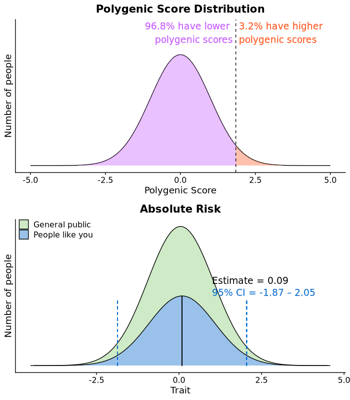

- Your PGS Z-score for Body Mass IndexBody Mass Index is 1.847 which is higher than 96.8% of other EUR individuals.
- Assuming the PGS explains 0.2% of the variance in Body Mass Index, and the mean and SD of Body Mass Index in the general population is 0 and 1 respectively, on average people with your PGS have a Body Mass Index of 0.09 (95% CI = -1.87 - 2.05).
- **Note.** These predictions are estimated using a range of assumptions and should be interpreted with caution. This report is merely a demonstration of how polygenic scores can be interpreted.

#### GWAS: Coronary Artery Disease

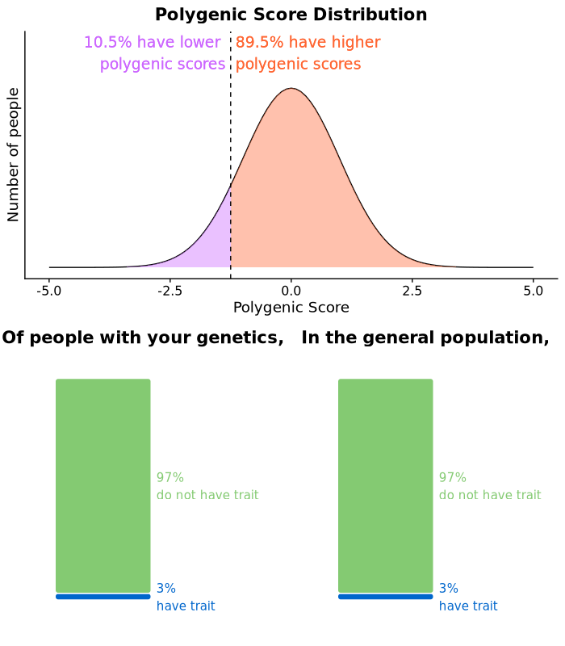

- Your PGS Z-score for Coronary Artery DiseaseCoronary Artery Disease is -1.251 which is higher than 10.5% of other EUR individuals.
- Assuming the PGS has an AUC of 0.5, and the prevelance of Coronary Artery Disease in the general population is 0.03, on average 3% of people with your PGS have Coronary Artery Disease.
- **Note.** These predictions are estimated using a range of assumptions and should be interpreted with caution. This report is merely a demonstration of how polygenic scores can be interpreted.

### Method: External

| Outcome | PGS Descriptives PGS R-squared | PGS Descriptives PGS AUC | Distribution in General Population Prevelance | Distribution in General Population Mean | Distribution in General Population SD | Distribution in People Like You PGS Z-score | Distribution in People Like You Prevalence | Distribution in People Like You Mean | Distribution in People Like You SD |
| --- | --- | --- | --- | --- | --- | --- | --- | --- | --- |
| Height Yengo EUR | NA | NA | NA | NA | NA | 0.228 | NA | NA | NA |
| BMI | NA | NA | NA | NA | NA | 0.958 | NA | NA | NA |

**Note.** PGS R-squared/AUC cannot be estimated when using externally derived score files. To specify parameters, check out our [interactive tool](https://opain.github.io/GenoPred/PRS_to_Abs_tool.html) for converting polygenic scores to the absolute scale.

#### GWAS: Height Yengo EUR

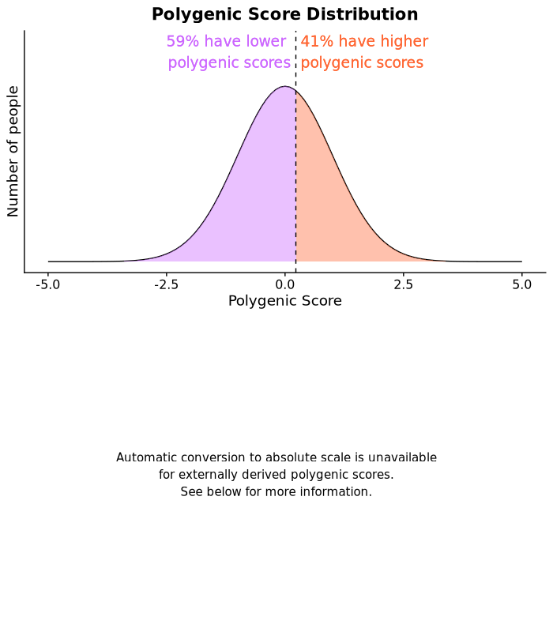

- Your PGS Z-score for Height Yengo EUR is 0.228 which is higher than 59% of other EUR individuals.

#### GWAS: BMI

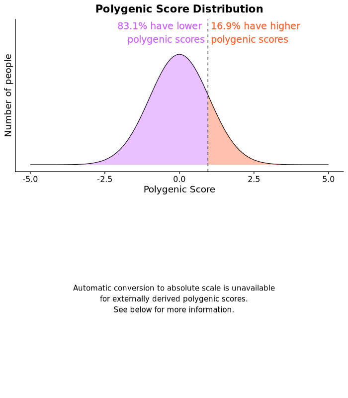

- Your PGS Z-score for BMI is 0.958 which is higher than 83.1% of other EUR individuals.

This report was created using GenoPred (v2.2.2-67-g53c5c77).